# Hello, R!

## Commen Data Type: Vector

( Tip)

```r
1:10  # numeric (integer/double)
```

```
##  [1]  1  2  3  4  5  6  7  8  9 10
```

```r
c("R", "workshop") # character
```

```
## [1] "R"        "workshop"
```

```r
3 == 5  # logical
```

```
## [1] FALSE
```

```r
factor(1:3, levels = 1:3, labels = c("low", "medium", "high"))  # factor
```

```
## [1] low    medium high
## Levels: low medium high
```

## Commen Data Type: Dataset

```r
matrix(1:4, ncol = 2)  # matrix
```

```
##      [,1] [,2]
## [1,]    1    3
## [2,]    2    4
```

```r
data.frame(x = 1:2, y = 3:4)  # data.frame
```

```
##   x y
## 1 1 3
## 2 2 4
```

```r
list(c("one", "two"), c(3, 4)) # 2-D list
```

```
## [[1]]
## [1] "one" "two"
##
## [[2]]
## [1] 3 4
```

```r
array(c(1:8), dim = c(2, 2, 3)) # 3-D or n-D "list""
```

```
## , , 1
##
##      [,1] [,2]
## [1,]    1    3
## [2,]    2    4
##
## , , 2
##
##      [,1] [,2]
## [1,]    5    7
## [2,]    6    8
##
## , , 3
##
##      [,1] [,2]
## [1,]    1    3
## [2,]    2    4
```

## Save data to an object

```r
x <- rep(c(.01, .05, .1), times = 2) # repeat 1:5 for twice
df <- data.frame(x = 1:1, y = 3:4)
list <- list(x, df)

list # == print(list)
```

```
## [[1]]
## [1] 0.01 0.05 0.10 0.01 0.05 0.10
##
## [[2]]
##   x y
## 1 1 3
## 2 1 4
```

Basic rules for object name:

- Don't start with numbers (WRONG: `1stday`)
- No special signs except for `.` and `-` (WRONG: `M&M`)
- Case sensitivity (`X != x`)

## Attributes of an object

- Structure

```r
str(df)
```

```
## 'data.frame':    2 obs. of  2 variables:
##  $ x: int  1 1
##  $ y: int  3 4
```

- Unique values ( Tip)

```r
unique(df$x)
```

```
## [1] 1
```

- Names

```r
names(df)
```

```
## [1] "x" "y"
```

Length

```r
length(x)
```

```
## [1] 6
```

Class

```r
class(x);typeof(x)  # ; is used to write two commands in one line
```

```
## [1] "numeric"
```

```
## [1] "double"
```

## Detect the attributes

Using `is.`

```r
x <-c(1, 2, NA, 4)
is.numeric(x)
```

```
## [1] TRUE
```

```r
is.na(x) # detect if x includes missing values
```

```
## [1] FALSE FALSE  TRUE FALSE
```

## Wrap up

- Set the working directory first: `setwd()`
- Four types of data: numeric, character, logical, factor
- Four types of datasets: matrix, data.frame, list, array
- Save the things into an object by `<-`
- Next: Data input

[figure not shown]

## Data Input and Manipulation

## Input default data types

- Default data types: .Rds, .Rdata(.Rda)

```r
load("<FileName>.RData")

df_txt <- read.table("<FileName>.txt")
df_csv <- read.csv("<FileName>.csv")
```

- Some data are already embedded in R. To call them, use `data()`, e.g.

```r
data(mtcars)
```

## Input data with packages

```r
# SPSS, Stata, SAS
library(haven)
df_spss <- read_spss("<FileName>.sav")
df_stata <- read_dta("<FileName>.dta")
df_sas <- read_sas("<FileName>.sas7bdat")

# Excel sheets
library(readxl)
df_excel <- read_excel("<FileName>.xls");read_excel("<FileName>.xlsx")

# JavaScript Object Notation
library(rjson)
df_json <- fromJSON(file = "<FileName>.json" )

# XML/Html
df_xml <- xmlTreeParse("<url>")
df_html <- readHTMLTable(url, which=3)
```

## Output data

- Save in a R dataset (`.RData`)

```r
save(object, file = "./Data/mydata.Rdata")
```

- Save as `.csv`

```r
write.csv(object, file = "mydata.csv")
```

- Save as `.feather` Tip

```r
feather::write_feather(mydata, "mydata.feather")
```

## Manipulate the data

- let's call a dataset first,

```r
data(mtcars)
```

- Variable numbers and Observations

```r
ncol(mtcars);names(mtcars)
```

```
## [1] 11
```

```
##  [1] "mpg"  "cyl"  "disp" "hp"   "drat" "wt"   "qsec" "vs"   "am"   "gear"
## [11] "carb"
```

```r
nrow(mtcars)
```

```
## [1] 32
```

## Have a glimpse

```r
dplyr::glimpse(mtcars)
```

```
## Observations: 32
## Variables: 11
## $ mpg  <dbl> 21.0, 21.0, 22.8, 21.4, 18.7, 18.1, 14.3, 24.4, 22.8, 19....
## $ cyl  <dbl> 6, 6, 4, 6, 8, 6, 8, 4, 4, 6, 6, 8, 8, 8, 8, 8, 8, 4, 4, ...
## $ disp <dbl> 160.0, 160.0, 108.0, 258.0, 360.0, 225.0, 360.0, 146.7, 1...
## $ hp   <dbl> 110, 110, 93, 110, 175, 105, 245, 62, 95, 123, 123, 180, ...
## $ drat <dbl> 3.90, 3.90, 3.85, 3.08, 3.15, 2.76, 3.21, 3.69, 3.92, 3.9...
## $ wt   <dbl> 2.620, 2.875, 2.320, 3.215, 3.440, 3.460, 3.570, 3.190, 3...
## $ qsec <dbl> 16.46, 17.02, 18.61, 19.44, 17.02, 20.22, 15.84, 20.00, 2...
## $ vs   <dbl> 0, 0, 1, 1, 0, 1, 0, 1, 1, 1, 1, 0, 0, 0, 0, 0, 0, 1, 1, ...
## $ am   <dbl> 1, 1, 1, 0, 0, 0, 0, 0, 0, 0, 0, 0, 0, 0, 0, 0, 0, 1, 1, ...
## $ gear <dbl> 4, 4, 4, 3, 3, 3, 3, 4, 4, 4, 4, 3, 3, 3, 3, 3, 3, 4, 4, ...
## $ carb <dbl> 4, 4, 1, 1, 2, 1, 4, 2, 2, 4, 4, 3, 3, 3, 4, 4, 4, 1, 2, ...
```

```r
head(mtcars) # show the first six lines of mtcars
```

```
##                    mpg cyl disp  hp drat    wt  qsec vs am gear carb
## Mazda RX4         21.0   6  160 110 3.90 2.620 16.46  0  1    4    4
## Mazda RX4 Wag     21.0   6  160 110 3.90 2.875 17.02  0  1    4    4
## Datsun 710        22.8   4  108  93 3.85 2.320 18.61  1  1    4    1
## Hornet 4 Drive    21.4   6  258 110 3.08 3.215 19.44  1  0    3    1
## Hornet Sportabout 18.7   8  360 175 3.15 3.440 17.02  0  0    3    2
## Valiant           18.1   6  225 105 2.76 3.460 20.22  1  0    3    1
```

## Let's zoom in

- locate a specific row, column, or cell of data: `data[row#, col#]` or `data["rowName","colName"]`.

```r
mtcars[1:2,3:4] # show first and the second rows of the third and fourth columns
```

```
##               disp  hp
## Mazda RX4      160 110
## Mazda RX4 Wag  160 110
```

```r
mtcars[ ,"mpg"] # show the column "mpg"
mtcars[ ,"mpg"][3]
```

- Select with special conditions

```r
mtcars[mtcars$mpg < 20,][1,] # show the first rows which mpg are below 5.
```

```
##                    mpg cyl disp  hp drat   wt  qsec vs am gear carb
## Hornet Sportabout 18.7   8  360 175 3.15 3.44 17.02  0  0    3    2
```

- Create new rows/columns

```r
mtcars$id <- seq(1:nrow(mtcars))
```

## Let's generalize

Summarise vector in categories

```r
unique(mtcars$cyl)
```

```
## [1] 6 4 8
```

```r
table(mtcars$cyl)
```

```
##
##  4  6  8
## 11  7 14
```

For a dataset or a numeric vector

```r
summary(mtcars$cyl)
```

```
##    Min. 1st Qu.  Median    Mean 3rd Qu.    Max.
##   4.000   4.000   6.000   6.188   8.000   8.000
```

One can use `mean`, `sd`, `max`, `min`, etc. to extract specific descriptive statistics.

```r
mean(mtcars$cyl)
```

```
## [1] 6.1875
```

## Let's create

- Create a variable into the dataset ( Tip)

```r
mtcars$newvar <- c(1:nrow(mtcars)) # create an "ID" variable
mtcars$newvar
```

```
##  [1]  1  2  3  4  5  6  7  8  9 10 11 12 13 14 15 16 17 18 19 20 21 22 23
## [24] 24 25 26 27 28 29 30 31 32
```

- Remove a variable from the dataset

```r
mtcars$newvar <- NULL
mtcars$newvar
```

Remove variable, result, function, or data from the environment

```r
rm(x)
```

Recode a variable: e.g., numeric to binary, mpg > mean, 1, otherwise 0

```r
# Method I
mtcars$newvar[mtcars$mpg > mean(mtcars$mpg)] <- 1
mtcars$newvar[mtcars$mpg <= mean(mtcars$mpg)] <- 0

# Method II
mtcars$newvar <- ifelse(mtcars$mpg > mean(mtcars$mpg), 1, 0) # overwrite the NAs
```

## Wrap Up

- Input/output: `load()`/`read.`series and `save()`/`write.`series
- A glimpse of data: `head()` or `dplyr::glimpse`
- Description: `summary()`, `table()`
  - More specific: `mean`, `sd`, `max`, `min`, etc.
- Manipulation:
  - create: `mtcars$newvar <- c(1:nrow(mtcars))`
  - Remove: `mtcars$newvar <- NULL`; `rm()`
  - Recode: `recodevar[<condition>] <- <new value>`
- There are also [`apply` family](http://www.r-bloggers.com/r-tutorial-on-the-apply-family-of-functions/) functions for with batching management of data.

Next: Hypothsis test

[figure not shown]

core

## Hypothesis Tests

## package loading

You want the `pacman` package to load multiple packages.

```r
pacman::p_load(dplyr)
```

## Data Glimpse

```r
data("mtcars")
dplyr::glimpse(mtcars)
```

```
## Observations: 32
## Variables: 11
## $ mpg  <dbl> 21.0, 21.0, 22.8, 21.4, 18.7, 18.1, 14.3, 24.4, 22.8, 19....
## $ cyl  <dbl> 6, 6, 4, 6, 8, 6, 8, 4, 4, 6, 6, 8, 8, 8, 8, 8, 8, 4, 4, ...
## $ disp <dbl> 160.0, 160.0, 108.0, 258.0, 360.0, 225.0, 360.0, 146.7, 1...
## $ hp   <dbl> 110, 110, 93, 110, 175, 105, 245, 62, 95, 123, 123, 180, ...
## $ drat <dbl> 3.90, 3.90, 3.85, 3.08, 3.15, 2.76, 3.21, 3.69, 3.92, 3.9...
## $ wt   <dbl> 2.620, 2.875, 2.320, 3.215, 3.440, 3.460, 3.570, 3.190, 3...
## $ qsec <dbl> 16.46, 17.02, 18.61, 19.44, 17.02, 20.22, 15.84, 20.00, 2...
## $ vs   <dbl> 0, 0, 1, 1, 0, 1, 0, 1, 1, 1, 1, 0, 0, 0, 0, 0, 0, 1, 1, ...
## $ am   <dbl> 1, 1, 1, 0, 0, 0, 0, 0, 0, 0, 0, 0, 0, 0, 0, 0, 0, 1, 1, ...
## $ gear <dbl> 4, 4, 4, 3, 3, 3, 3, 4, 4, 4, 4, 3, 3, 3, 3, 3, 3, 4, 4, ...
## $ carb <dbl> 4, 4, 1, 1, 2, 1, 4, 2, 2, 4, 4, 3, 3, 3, 4, 4, 4, 1, 2, ...
```

## Binary Tests: Difference in mean

```r
t.test(mtcars$cyl, mtcars$gears)
```

```
##
##  One Sample t-test
##
## data:  mtcars$cyl
## t = 19.599, df = 31, p-value < 2.2e-16
## alternative hypothesis: true mean is not equal to 0
## 95 percent confidence interval:
##  5.543607 6.831393
## sample estimates:
## mean of x
##    6.1875
```

`t.test` offers arguments `alternative`, `mu`, `paired`, and `conf.level` for users to change in two-tail/one-tail test, parameter mean, independent/paired comparison, and \(\alpha\).

```r
# one side, cyl > gear, alpha = .01
t.test(mtcars$cyl, mtcars$gear,
       alternative = "greater", conf.level = .99))

# comparing with the parameter (true value)
t.test(mtcars$cyl, mu = 6)   # the true mean is 6.
```

## Binary Tests: Correlation

\(H_{0}: \rho_{(cyl,gear)} = 0,\ \alpha = .05\)

```r
cor.test(mtcars$cyl, mtcars$gear)
```

```
##
##  Pearson's product-moment correlation
##
## data:  mtcars$cyl and mtcars$gear
## t = -3.1011, df = 30, p-value = 0.004173
## alternative hypothesis: true correlation is not equal to 0
## 95 percent confidence interval:
##  -0.7180260 -0.1738615
## sample estimates:
##        cor
## -0.4926866
```

`cor.test` offers various arguments as in `t.test` for more specific settings. Moreover, users can use the `method` argument to set the method to calculate the correlations, "Pearson", "Kendall", or "Spearman." ( Tip)

```r
cor.test(mtcars$cyl, mtcars$gear, method = "kendall")
```

```
##
##  Kendall's rank correlation tau
##
## data:  mtcars$cyl and mtcars$gear
## z = -3.1551, p-value = 0.001604
## alternative hypothesis: true tau is not equal to 0
## sample estimates:
##        tau
## -0.5125435
```

We can get the correlation matrix, too:

```r
cor(mtcars[,1:4])
```

```
##             mpg        cyl       disp         hp
## mpg   1.0000000 -0.8521620 -0.8475514 -0.7761684
## cyl  -0.8521620  1.0000000  0.9020329  0.8324475
## disp -0.8475514  0.9020329  1.0000000  0.7909486
## hp   -0.7761684  0.8324475  0.7909486  1.0000000
```

## Present the correlations

You want the `corrplot` package.

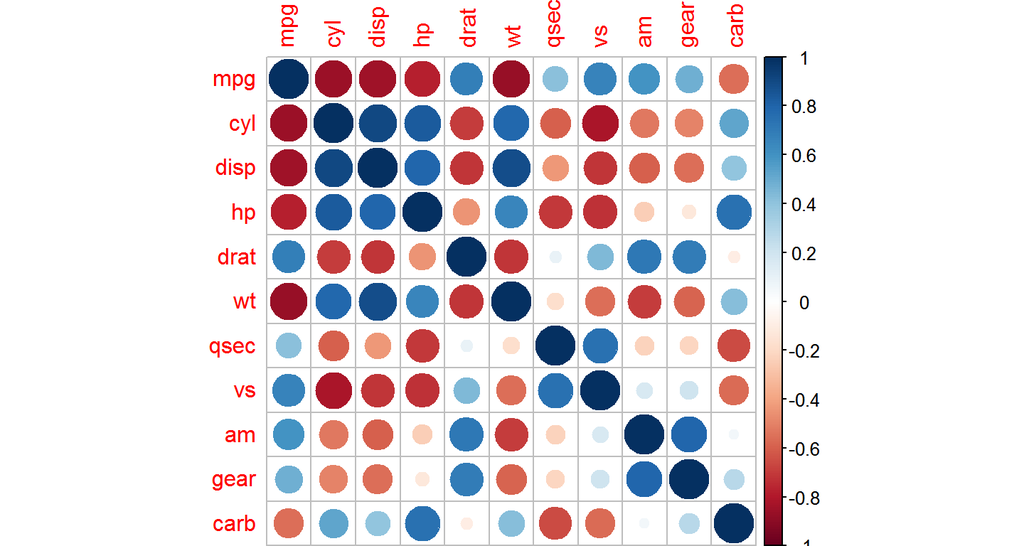

```r
cor(mtcars) %>% corrplot::corrplot()
```

Or a mixed format:

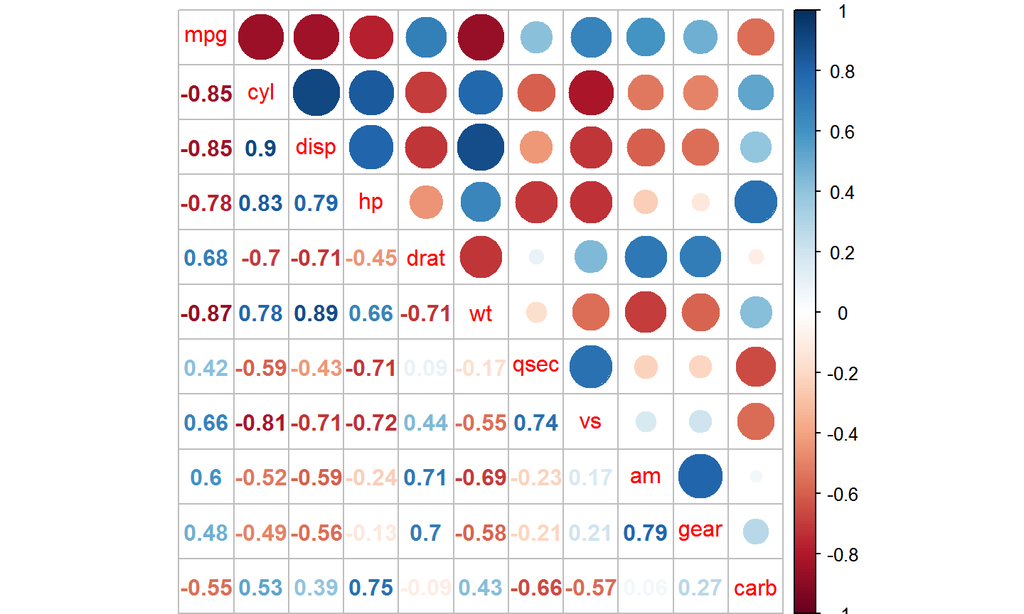

```r
cor(mtcars) %>% corrplot::corrplot.mixed()
```

## Binary Tests: ANOVA

One way or two way ANOVA:

```r
aov_one <- aov(cyl ~ gear, data = mtcars) #one-way

aov_two <- aov(cyl ~ gear + am, data = mtcars) #two-way

summary(aov_one); summary(aov_two)
```

```
##             Df Sum Sq Mean Sq F value  Pr(>F)
## gear         1  24.00  24.001   9.617 0.00417 **
## Residuals   30  74.87   2.496
## ---
## Signif. codes:  0 '***' 0.001 '**' 0.01 '*' 0.05 '.' 0.1 ' ' 1
```

```
##             Df Sum Sq Mean Sq F value  Pr(>F)
## gear         1  24.00  24.001   9.907 0.00379 **
## am           1   4.62   4.620   1.907 0.17786
## Residuals   29  70.25   2.423
## ---
## Signif. codes:  0 '***' 0.001 '**' 0.01 '*' 0.05 '.' 0.1 ' ' 1
```

## Wrap up

- T-test: `t.test(x, y = NULL, alternative = c("two.sided", "less", "greater"), mu = 0, paired = FALSE, conf.level = 0.95, ...)`
- Correlation: `cor.test(x, y, alternative = c("two.sided", "less", "greater"), method = c("pearson", "kendall", "spearman"), conf.level = 0.95, continuity = FALSE, ...)`
- ANOVA: `aov(formula, data = NULL, ...)`

Next: Multiple regression

[figure not shown]

core

## Multiple Regression

## Ordinary Linear Regression

\(Mileage = \beta_0cylinders + \beta_1horsepower + \beta_3weight + \varepsilon\)

```r
lm_ols <- lm(mpg ~ cyl + hp + wt, data = mtcars)
```

- `lm_ols`: Object name
- `mpg`: Dependent variable
- `cyl + hp + wt`: Independent variables
- `data = mtcars`: Where the variables are stored

## Result

```r
summary(lm_ols)
```

```
##
## Call:
## lm(formula = mpg ~ cyl + hp + wt, data = mtcars)
##
## Residuals:
##     Min      1Q  Median      3Q     Max
## -3.9290 -1.5598 -0.5311  1.1850  5.8986
##
## Coefficients:
##             Estimate Std. Error t value Pr(>|t|)
## (Intercept) 38.75179    1.78686  21.687  < 2e-16 ***
## cyl         -0.94162    0.55092  -1.709 0.098480 .
## hp          -0.01804    0.01188  -1.519 0.140015
## wt          -3.16697    0.74058  -4.276 0.000199 ***
## ---
## Signif. codes:  0 '***' 0.001 '**' 0.01 '*' 0.05 '.' 0.1 ' ' 1
##
## Residual standard error: 2.512 on 28 degrees of freedom
## Multiple R-squared:  0.8431, Adjusted R-squared:  0.8263
## F-statistic: 50.17 on 3 and 28 DF,  p-value: 2.184e-11
```

## Nonlinear transition

ln, square, exponential, or inverse

```r
lm_tran <- lm(log(mpg) ~ I(cyl^2) + exp(hp) + I(1/wt), data = mtcars)
```

## The result

```r
summary(lm_tran)
```

```
##
## Call:
## lm(formula = log(mpg) ~ I(cyl^2) + exp(hp) + I(1/wt), data = mtcars)
##
## Residuals:
##      Min       1Q   Median       3Q      Max
## -0.27532 -0.06730 -0.01030  0.08334  0.24674
##
## Coefficients:
##                Estimate  Std. Error t value Pr(>|t|)
## (Intercept)   2.770e+00   1.633e-01  16.958 2.92e-16 ***
## I(cyl^2)     -6.282e-03   1.664e-03  -3.775 0.000765 ***
## exp(hp)     -8.547e-148  4.283e-147  -0.200 0.843268
## I(1/wt)       1.308e+00   3.022e-01   4.329 0.000173 ***
## ---
## Signif. codes:  0 '***' 0.001 '**' 0.01 '*' 0.05 '.' 0.1 ' ' 1
##
## Residual standard error: 0.1271 on 28 degrees of freedom
## Multiple R-squared:  0.8354, Adjusted R-squared:  0.8178
## F-statistic: 47.38 on 3 and 28 DF,  p-value: 4.26e-11
```

## Adding binary variables

When the model including binary variables based on a factor

```r
mtcars$gear_f <- factor(mtcars$gear, levels = 3:5, labels = c("3-gear", "4-gear", "5-gear"))
table(mtcars$gear)
```

```
##
##  3  4  5
## 15 12  5
```

```r
table(mtcars$gear_f); class(mtcars$gear_f)
```

```
##
## 3-gear 4-gear 5-gear
##     15     12      5
```

```
## [1] "factor"
```

## The result

```r
lm_f <- lm(mpg ~ cyl + hp + wt + gear_f, data = mtcars)
summary(lm_f)
```

```
##
## Call:
## lm(formula = mpg ~ cyl + hp + wt + gear_f, data = mtcars)
##
## Residuals:
##     Min      1Q  Median      3Q     Max
## -3.4107 -1.7394 -0.6204  1.2435  5.9357
##
## Coefficients:
##              Estimate Std. Error t value Pr(>|t|)
## (Intercept)  37.67538    3.49111  10.792 4.24e-11 ***
## cyl          -0.80485    0.68114  -1.182  0.24805
## hp           -0.02116    0.01712  -1.236  0.22757
## wt           -3.03971    0.88754  -3.425  0.00205 **
## gear_f4-gear  0.46155    1.49468   0.309  0.75994
## gear_f5-gear  0.67475    2.11262   0.319  0.75198
## ---
## Signif. codes:  0 '***' 0.001 '**' 0.01 '*' 0.05 '.' 0.1 ' ' 1
##
## Residual standard error: 2.6 on 26 degrees of freedom
## Multiple R-squared:  0.844,  Adjusted R-squared:  0.814
## F-statistic: 28.12 on 5 and 26 DF,  p-value: 1.04e-09
```

## Interaction

Two-way interaction: horsepower * Weight

```r
lm_in <- lm(mpg ~ cyl + hp * wt, data = mtcars)
```

Equivalent to `lm_in2 <- lm(mpg ~ cyl + hp + wt + hp:wt, data = mtcars)`

## The result

```r
summary(lm_in)
```

```
##
## Call:
## lm(formula = mpg ~ cyl + hp * wt, data = mtcars)
##
## Residuals:
##     Min      1Q  Median      3Q     Max
## -3.3917 -1.6444 -0.6117  1.4213  4.5530
##
## Coefficients:
##              Estimate Std. Error t value Pr(>|t|)
## (Intercept) 49.490987   3.663514  13.509 1.58e-13 ***
## cyl         -0.365239   0.508620  -0.718  0.47887
## hp          -0.108394   0.029775  -3.640  0.00114 **
## wt          -7.627489   1.521056  -5.015 2.93e-05 ***
## hp:wt        0.025837   0.007992   3.233  0.00322 **
## ---
## Signif. codes:  0 '***' 0.001 '**' 0.01 '*' 0.05 '.' 0.1 ' ' 1
##
## Residual standard error: 2.172 on 27 degrees of freedom
## Multiple R-squared:  0.8869, Adjusted R-squared:  0.8702
## F-statistic: 52.94 on 4 and 27 DF,  p-value: 2.156e-12
```

## Post-estimate diagnoses: Residural

```r
res <- resid(lm_ols); res[1:4]
```

```
##      Mazda RX4  Mazda RX4 Wag     Datsun 710 Hornet 4 Drive
##     -1.8204257     -1.0128476     -3.1603990      0.4639233
```

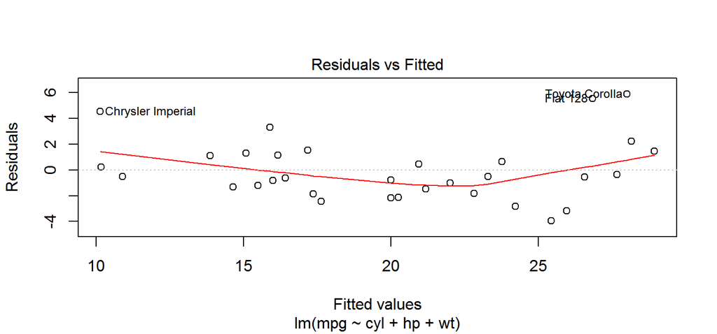

```r
plot(lm_ols, which = 1) # residural vs. fitted plot
```

## Post-estimate diagnoses: Outliers

```r
car::outlierTest(lm_ols) # Bonferonni p-value for most extreme obs
```

```
##
## No Studentized residuals with Bonferonni p < 0.05
## Largest |rstudent|:
##                rstudent unadjusted p-value Bonferonni p
## Toyota Corolla 2.749837           0.010508      0.33625
```

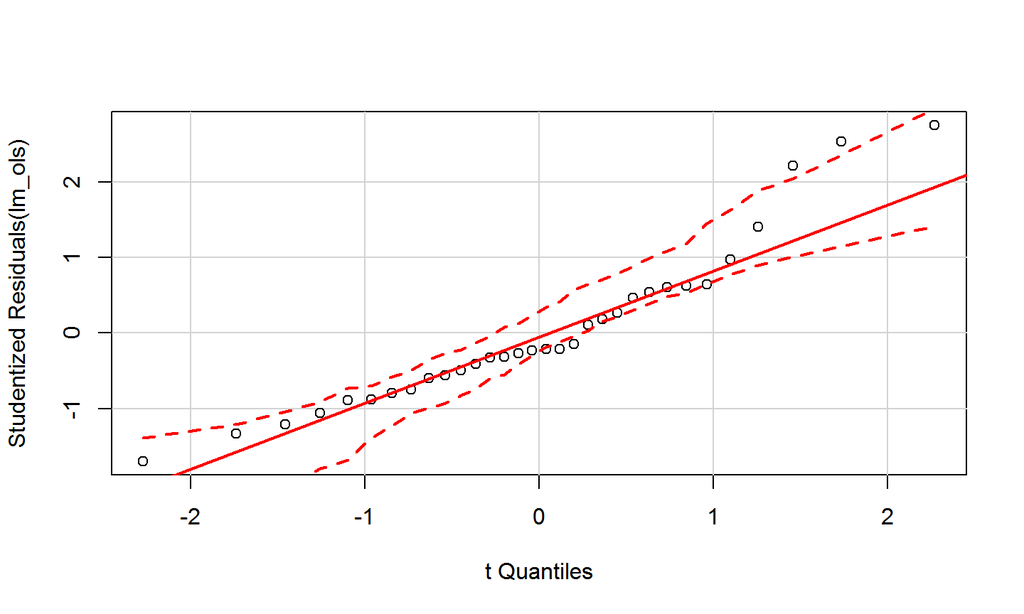

```r
car::qqPlot(lm_ols)  #qq plot for studentized resid
```

## Post-estimate diagnoses: CLRM Properties

- Heteroscedasticity

```r
car::ncvTest(lm_ols)
```

```
## Non-constant Variance Score Test
## Variance formula: ~ fitted.values
## Chisquare = 2.882097    Df = 1     p = 0.08956928
```

- Multicollinearity

```r
car::vif(lm_ols)
```

```
##      cyl       hp       wt
## 4.757456 3.258481 2.580486
```

Autocorrelation

```r
car::durbinWatsonTest(lm_ols)
```

```
##  lag Autocorrelation D-W Statistic p-value
##    1        0.146151       1.64407     0.2
##  Alternative hypothesis: rho != 0
```

## Logit

\(vs = \frac{1}{1 + e^{-(\beta_0 + \beta_1cylinder + \beta_2horsepower + \beta_3weight + \varepsilon)}}\)

```r
logit <- glm(vs ~ cyl + hp + wt, data = mtcars, family = "binomial")
```

MLE on other distributions: change the value of the argument `family` to `Gamma`, `poisson`, `gaussian`, etc.

## The result

```r
summary(logit)
```

```
##
## Call:
## glm(formula = vs ~ cyl + hp + wt, family = "binomial", data = mtcars)
##
## Deviance Residuals:
##      Min        1Q    Median        3Q       Max
## -2.41745  -0.12944  -0.00758   0.24675   1.24429
##
## Coefficients:
##             Estimate Std. Error z value Pr(>|z|)
## (Intercept)  9.95269    4.38923   2.268   0.0234 *
## cyl         -2.16258    1.50997  -1.432   0.1521
## hp          -0.05270    0.03552  -1.484   0.1379
## wt           2.97179    1.90352   1.561   0.1185
## ---
## Signif. codes:  0 '***' 0.001 '**' 0.01 '*' 0.05 '.' 0.1 ' ' 1
##
## (Dispersion parameter for binomial family taken to be 1)
##
##     Null deviance: 43.860  on 31  degrees of freedom
## Residual deviance: 12.698  on 28  degrees of freedom
## AIC: 20.698
##
## Number of Fisher Scoring iterations: 7
```

## Interpretation: Margin

```r
library(mfx)
logit_m <- logitmfx(vs ~ cyl + hp + wt, data = mtcars)
logit_m
```

```
## Call:
## logitmfx(formula = vs ~ cyl + hp + wt, data = mtcars)
##
## Marginal Effects:
##          dF/dx  Std. Err.       z   P>|z|
## cyl -0.3028436  0.2629609 -1.1517 0.24946
## hp  -0.0073793  0.0043738 -1.6872 0.09157 .
## wt   0.4161633  0.2899976  1.4351 0.15127
## ---
## Signif. codes:  0 '***' 0.001 '**' 0.01 '*' 0.05 '.' 0.1 ' ' 1
```

## Interpretation: Predicted probability

Predicted Probability when `cyl` changes from 4 to 6.

```r
# Step 1: creat an aggregate data
mtcars_fake <- with(mtcars, data.frame(cyl = 4:6, hp = mean(hp), wt = mean(wt)))
# Step 2: predict based on the new data
logit_pp4 <- cbind(mtcars_fake,predict(logit, newdata = mtcars_fake, type = "link", se = TRUE))
# Step 3: convert to probability
logit_pp4 <- within(logit_pp4, {pp <- plogis(fit)
                                lb <- plogis(fit - 1.96 * se.fit)
                                ub <- plogis(fit + 1.96 * se.fit)})
logit_pp4[,7:9]
```

```
##          ub         lb        pp
## 1 0.9999189 0.04100710 0.9582577
## 2 0.9899843 0.06589691 0.7253227
## 3 0.7048727 0.03719288 0.2329796
```

## Wrap Up

- OLS: `lm(Y ~ X, data = data)`
  - Non-linear transformations: `I(X^2)`, `exp(X)`, `log(X)`.
  - Using factor variable: R will handle that for you.
  - Interaction: `lm(Y ~ X * Z, data = data)`.
  - Post-estimate diagnoses: `resid()`, `outlierTest()`, `qqPlot()`, `ncvTest()`, `vif()`, `durbinWatsonTest()`
- Logit: `glm(Y ~ X, data = data, family = "binomial")`
  - Margins: using `mfx::logitmfx`
  - Predict probabilty:
    - Step 1: create an aggregate data
    - Step 2: predict the log odds
    - Step 3: transfer to probability

Next: Presenting with R

[figure not shown]

## Presentation with R

## Tabling

There are over twenty packages for [table presentation](http://conjugateprior.org/2013/03/r-to-latex-packages-coverage/) in R. My favoriate three are `stargazer`, `xtable`, and `texreg`.

(Sorry, but all of them are for **Latex** output)

- `stargazer`: good for summary table and regular regression results
- `texreg`: when some results can't be presented by `stargazer`, try `texreg` (e.g., MLM results.)
- `xtable`: the most extensively compatible package, but need more settings to get a pretty output, most of which `stargazer` and `texreg` can automatically do for you.

## An example

```r
lm_ols <- lm(mpg ~ cyl + hp + wt, data = mtcars)
stargazer::stargazer(lm_ols, type = "text", align = T)
```

```
##
## ===============================================
##                         Dependent variable:
##                     ---------------------------
##                                 mpg
## -----------------------------------------------
## cyl                           -0.942*
##                               (0.551)
##
## hp                            -0.018
##                               (0.012)
##
## wt                           -3.167***
##                               (0.741)
##
## Constant                     38.752***
##                               (1.787)
##
## -----------------------------------------------
## Observations                    32
## R2                             0.843
## Adjusted R2                    0.826
## Residual Std. Error       2.512 (df = 28)
## F Statistic           50.171*** (df = 3; 28)
## ===============================================
## Note:               *p<0.1; **p<0.05; ***p<0.01
```

Present in PDF

[figure not shown]

- For the users of MS Word, click [here](http://www.r-statistics.com/2010/05/exporting-r-output-to-ms-word-with-r2wd-an-example-session/).

## But…why tabulating if you can plot?

Three types of graphic presenting approaches in R:

- Basic plots: `plot()`.
- Lattice plots: e.g., `ggplot()`.
- Interactive plots: `shiny()`. (save for later)

[figure not shown]

## Basic plot

Pro:

- Embedded in R
- Good tool for data exploration.
- Spatial analysis and 3-D plots.

Con:

- Not very pretty
- Not very flexible

## An example: create a histogram

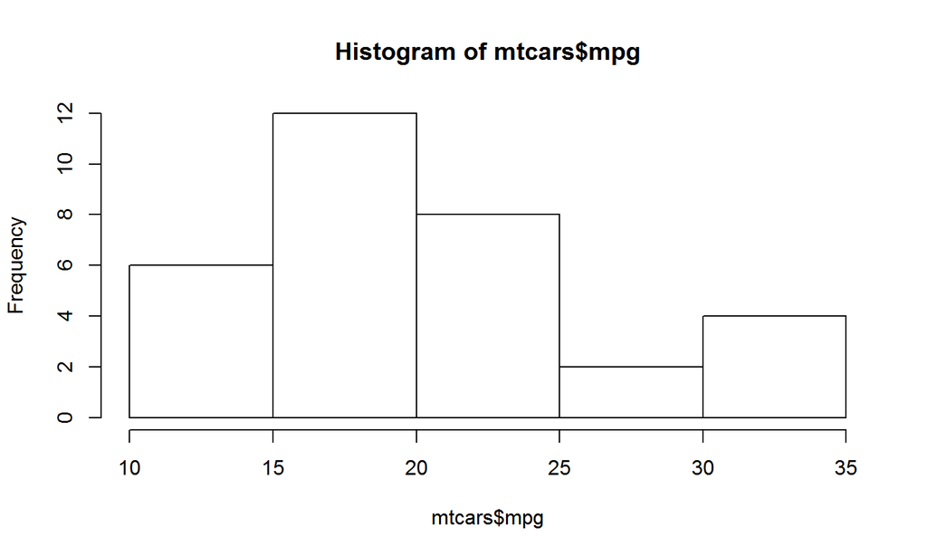

```r
hist(mtcars$mpg)
```

## Saving the plot

- Compatible format:`.jpg`, `.png`, `.wmf`, `.pdf`, `.bmp`, and `postscript`.
- Process:
  1. call the graphic device
  2. plot
  3. close the device

```r
jpeg("histgraph.jpg")
hist
dev.off()
```

Tip

The device list:

| Function | Output to |
| --- | --- |
| pdf("mygraph.pdf") | pdf file |
| win.metafile("mygraph.wmf") | windows metafile |
| png("mygraph.png") | png file |
| jpeg("mygraph.jpg") | jpeg file |
| bmp("mygraph.bmp") | bmp file |
| postscript("mygraph.ps") | postscript file |

## `ggplot`: the most popular graphic engine in R

- Built by Hadley Wickham based on Leland Wilkinson's *Grammar of Graphics*.
- It breaks the plot into components as scales and layers—increase the flexibility.
- To use `ggplot`, one needs to install the package `ggplot2` first.

```r
library(ggplot2)
```

## Histogram in `ggplot`

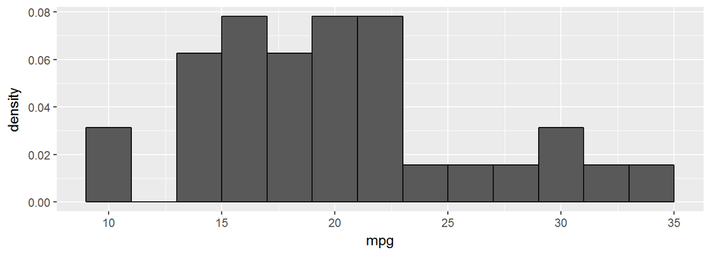

```r
ggplot(mtcars, aes(x=mpg)) +
    geom_histogram(aes(y=..density..), binwidth=2, colour="black")
```

## Decoration

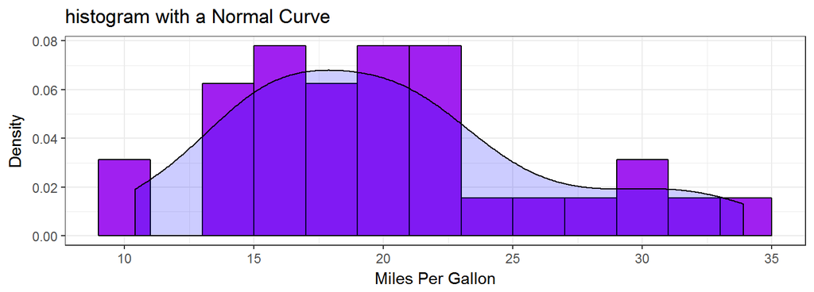

```r
ggplot(mtcars, aes(x=mpg)) +
    geom_histogram(aes(y=..density..), binwidth=2, colour="black", fill="purple") +
    geom_density(alpha=.2, fill="blue")  + # Overlay with transparent density plot
    theme_bw() + ggtitle("histogram with a Normal Curve") +
    xlab("Miles Per Gallon") + ylab("Density")
```

## Break in Parts:

```r
ggplot(data = mtcars, aes(x=mpg)) +
    geom_histogram(aes(y=..density..), binwidth=2, colour="black", fill="purple") +
    geom_density(alpha=.2, fill="blue")  + # Overlay with transparent density plot
    theme_bw() + ggtitle("histogram with a Normal Curve") +
    xlab("Miles Per Gallon") + ylab("Density")
```

- `data`: The data that you want to visualise
- `aes`: Aesthetic mappings describing how variables in the data are mapped to aesthetic attributes
  - horizontal position (`x`)
  - vertical position (`y`)
  - colour
  - size
- `geoms`: Geometric objects that represent what you actually see on the plot
  - points
  - lines
  - polygons
  - bars
- `theme`, `ggtitle`, `xlab`, `ylab`: decorations.
- Other parts you may see in some developed template
  - `stats`: Statistics transformations
  - `scales`: relate the data to the aesthetic
  - `coord`: a coordinate system that describes how data coordinates are mapped to the plane of the graphic.
  - `facet`: a faceting specification describes how to break up the data into sets.

## Save `ggplot`

- `ggsave(<plot project>, "<name + type>")`:
  - When the `<plot project>` is omitted, R will save the last presented plot.
  - There are additional arguments which users can use to adjust the size, path, scale, etc.

## Plotting with packages: Map

```r
starbucks <- read.csv("https://opendata.socrata.com/api/views/ddym-zvjk/rows.csv?accessType=DOWNLOAD")


library(leaflet)
leaflet() %>% addTiles() %>%
  setView(-91.535632, 41.660965, zoom = 16) %>%
  addMarkers(data = starbucks, lat = ~Latitude, lng = ~Longitude, popup = starbucks$Name)
```

[interactive chart not shown]

## Plotting with packages: `dotwhisker`

Plot the comparable coefficients or other estimates (margins, predicted probabilities, etc.).

```r
library(dotwhisker)
library(broom)
m1 <- lm(mpg ~ wt + cyl + disp + gear, data = mtcars)
```

```r
summary(m1)
```

```
##
## Call:
## lm(formula = mpg ~ wt + cyl + disp + gear, data = mtcars)
##
## Residuals:
##     Min      1Q  Median      3Q     Max
## -4.9159 -1.2484 -0.3566  1.4719  5.9253
##
## Coefficients:
##              Estimate Std. Error t value Pr(>|t|)
## (Intercept) 43.539847   4.860059   8.959 1.42e-09 ***
## wt          -3.792867   1.081819  -3.506  0.00161 **
## cyl         -1.784296   0.613889  -2.907  0.00722 **
## disp         0.006944   0.012007   0.578  0.56782
## gear        -0.490445   0.790285  -0.621  0.54007
## ---
## Signif. codes:  0 '***' 0.001 '**' 0.01 '*' 0.05 '.' 0.1 ' ' 1
##
## Residual standard error: 2.624 on 27 degrees of freedom
## Multiple R-squared:  0.835,  Adjusted R-squared:  0.8105
## F-statistic: 34.15 on 4 and 27 DF,  p-value: 3.36e-10
```

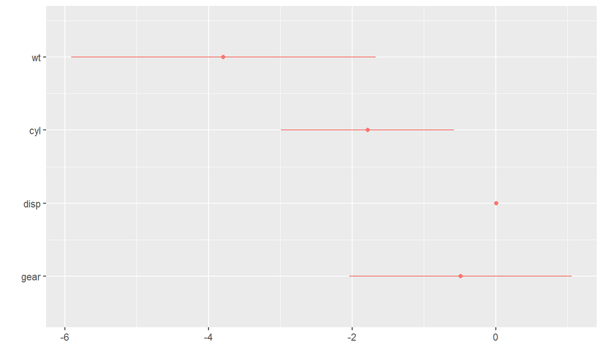

```r
dwplot(m1)
```

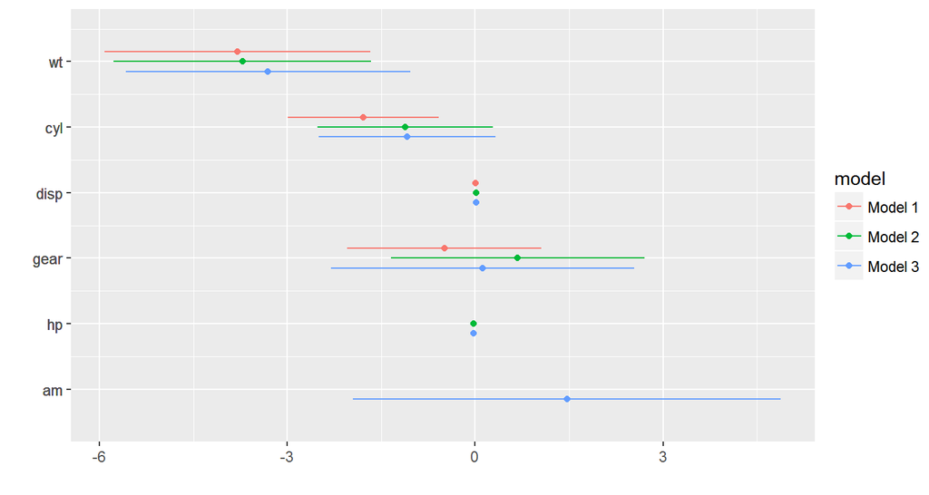

```r
m2 <- update(m1, . ~ . + hp) # add another predictor
m3 <- update(m2, . ~ . + am) # and another

dwplot(list(m1, m2, m3))
```

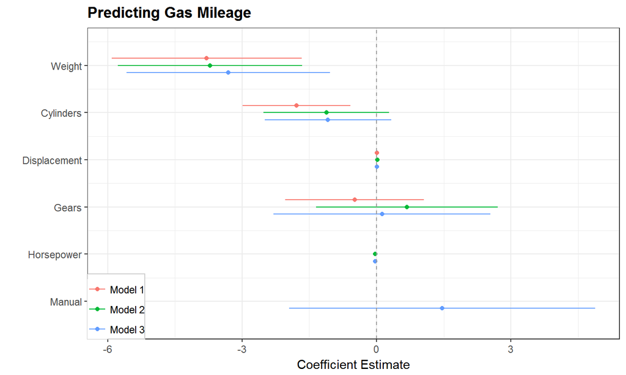

```r
dwplot(list(m1, m2, m3)) +
     relabel_y_axis(c("Weight", "Cylinders", "Displacement",
                     "Gears", "Horsepower", "Manual")) +
     theme_bw() + xlab("Coefficient Estimate") + ylab("") +
     geom_vline(xintercept = 0, colour = "grey60", linetype = 2) +
     ggtitle("Predicting Gas Mileage") +
     theme(plot.title = element_text(face="bold"),
           legend.justification=c(0, 0), legend.position=c(0, 0),
           legend.background = element_rect(colour="grey80"),
           legend.title = element_blank())
```

## Plotting with packages: `interplot`

```r
library(interplot)
lm_in <- lm(mpg ~ cyl + hp * wt, data = mtcars)
summary(lm_in)
```

```
##
## Call:
## lm(formula = mpg ~ cyl + hp * wt, data = mtcars)
##
## Residuals:
##     Min      1Q  Median      3Q     Max
## -3.3917 -1.6444 -0.6117  1.4213  4.5530
##
## Coefficients:
##              Estimate Std. Error t value Pr(>|t|)
## (Intercept) 49.490987   3.663514  13.509 1.58e-13 ***
## cyl         -0.365239   0.508620  -0.718  0.47887
## hp          -0.108394   0.029775  -3.640  0.00114 **
## wt          -7.627489   1.521056  -5.015 2.93e-05 ***
## hp:wt        0.025837   0.007992   3.233  0.00322 **
## ---
## Signif. codes:  0 '***' 0.001 '**' 0.01 '*' 0.05 '.' 0.1 ' ' 1
##
## Residual standard error: 2.172 on 27 degrees of freedom
## Multiple R-squared:  0.8869, Adjusted R-squared:  0.8702
## F-statistic: 52.94 on 4 and 27 DF,  p-value: 2.156e-12
```

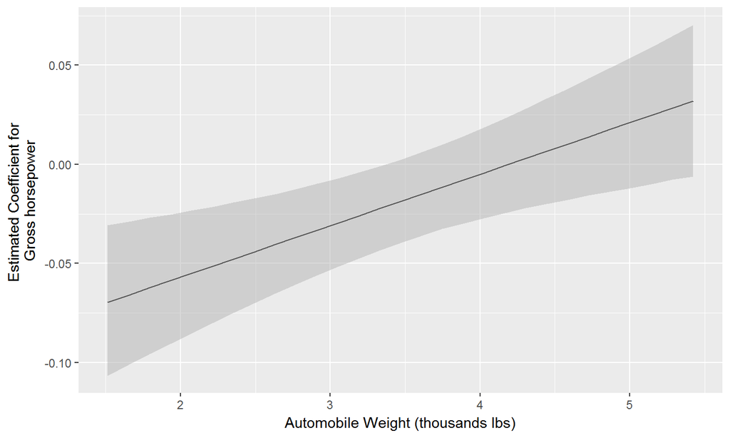

```r
interplot(m = lm_in, var1 = "hp", var2 = "wt") +
  xlab("Automobile Weight (thousands lbs)") +
  ylab("Estimated Coefficient for \nGross horsepower")
```

## Almost the end: one topic left

[

[figure not shown]

]

## Version Control

## Just a brief introduction

[figure not shown]

- Tried to recall the deleted codes?
- Tried to figure out what changes?
- Saved a lot of replication files?
- Version control can help you.

[figure not shown]

## Using Git with RStudio

- RStudio has associate with the Git and SVN very well.
- Process to use git:
  - Register a user account in https://github.com.
  - Connect your account with RStudio following [this instruction](http://www.molecularecologist.com/2013/11/using-github-with-r-and-rstudio/).
  - Create a version-control project in RStudio

[figure not shown]

  - Commit, Pull and Push

## External Sources

- Q&A Blogs:
  - http://stackoverflow.com/questions/tagged/r
  - https://stat.ethz.ch/mailman/listinfo/r-help
- Blog for new stuffs: http://www.r-bloggers.com/
- Graph Blogs:
  - http://www.cookbook-r.com/Graphs/
  - http://shiny.stat.ubc.ca/r-graph-catalog/
- Workshops: http://ppc.uiowa.edu/node/3608
- Consulting service: http://ppc.uiowa.edu/node/3385/

[

[figure not shown]

]